# AccSamplingDesign: Acceptance Sampling Plan Design - R Package

Ha Truong

2026-10-02

# 1 Introduction

The **AccSamplingDesign** package provides tools to create and evaluate acceptance sampling plans for both attribute and variable quality data. The focus is on controlling producer’s and consumer’s risk specifications while minimizing required sample sizes.

The package and its statistical foundations are described by Truong, Miranda, and Kissling (2026), [*AccSamplingDesign: An R Package for Optimizing Acceptance Sampling Plans*](https://doi.org/10.32614/RJ-2026-007), in *The R Journal*.

The package supports:

- Attributes sampling plans (e.g., pass/fail outcomes)
- Variables sampling plans under Normal and Beta distributions
- Easy-to-use functions for computing acceptance probability and visualizing OC curves

Install from CRAN:

```r
install.packages("AccSamplingDesign")
```

Or from GitHub:

```r
devtools::install_github("vietha/AccSamplingDesign")
```

# 2 Attributes Sampling Examples

```r
# Create an attribute plan with binomial assumption
plan_attr <- optPlan(
  PRQ = 0.01,   # Acceptable quality level (1%)
  CRQ = 0.05,   # Rejectable quality level (5%)
  alpha = 0.02, # Producer's risk
  beta = 0.15,  # Consumer's risk
  distribution = "binomial"
)

# Summary of the plan
summary(plan_attr)
```

```
#> Attributes Acceptance Sampling Plan:
#>  Distribution: binomial
#>  Sample Size (n): 144
#>  Acceptance Number (c): 4
#>  Producer's Risk (PR = 0.01534843 ) at PRQ = 0.01
#>  Consumer's Risk (CR = 0.1487162 ) at CRQ = 0.05
```

```r
# Probability of accepting 3% defective
accProb(plan_attr, 0.03)
```

```
#> [1] 0.5656415
```

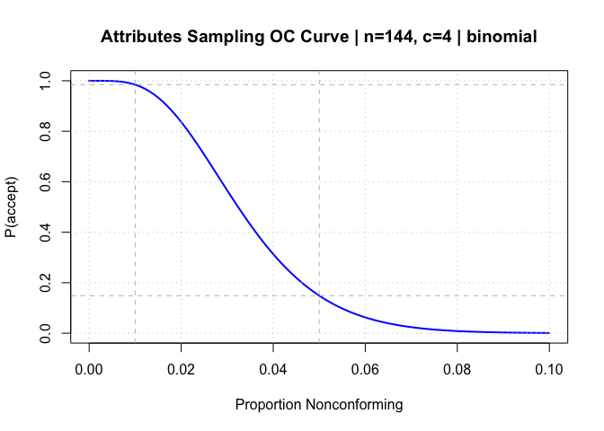

```r
# Plot the OC curve
plot(plan_attr)
```

# 3 Variables Sampling Examples

## 3.1 Normal Distribution, Known Sigma

```r
# Create a variable plan assuming known sigma
plan_var <- optPlan(
  PRQ = 0.025,
  CRQ = 0.1,
  alpha = 0.05,
  beta = 0.10,
  distribution = "normal",
  sigma_type = "known"
)

# Summary
summary(plan_var)
```

```
#> Variables Acceptance Sampling Plan
#>  Distribution: normal
#>  Sample Size (n, rounded up): 19  [raw n = 18.60721 ]
#>  Acceptability Constant (k): 1.579
#>  Population Standard Deviation: known
#>  Producer's Risk (PR = 0.05 ) at PRQ = 0.025
#>  Consumer's Risk (CR = 0.1 ) at CRQ = 0.1
```

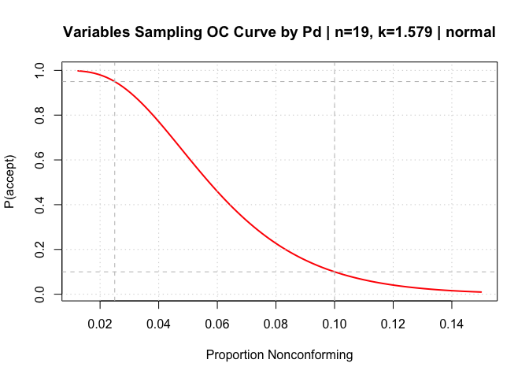

```r
# Plot OC curve
plot(plan_var)
```

## 3.2 Normal Distribution, Unknown Sigma

```r
# Create a variable plan assuming known sigma
plan_var2 <- optPlan(
  PRQ = 0.025,
  CRQ = 0.1,
  alpha = 0.05,
  beta = 0.10,
  distribution = "normal",
  sigma_type = "unknown"
)

# Summary
summary(plan_var2)
```

```
#> Variables Acceptance Sampling Plan
#>  Distribution: normal
#>  Sample Size (n, rounded up): 43  [raw n = 42.67339 ]
#>  Acceptability Constant (k): 1.586
#>  Population Standard Deviation: unknown
#>  Producer's Risk (PR = 0.05 ) at PRQ = 0.025
#>  Consumer's Risk (CR = 0.1 ) at CRQ = 0.1
```

## 3.3 Beta Distribution, Known Theta

```r
# Create a variable plan using Beta distribution
plan_beta <- optPlan(
  PRQ = 0.05,
  CRQ = 0.2,
  alpha = 0.05,
  beta = 0.10,
  distribution = "beta",
  theta = 44000000,
  theta_type = "known",
  LSL = 0.00001          # Lower Specification Limit
)

# Summary
summary(plan_beta)
```

```
#> Variables Acceptance Sampling Plan
#>  Distribution: beta
#>  Sample Size (n): 14
#>  Acceptability Constant (k): 1.185
#>  Population Precision Parameter (theta): known
#>  Producer's Risk (PR = 0.04718549 ) at PRQ = 0.05
#>  Consumer's Risk (CR = 0.09627747 ) at CRQ = 0.2
#>  Lower Specification Limit (LSL): 1e-05
```

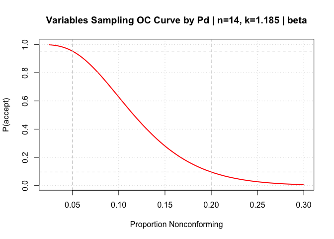

```r
# Plot OC curve
plot(plan_beta)
```

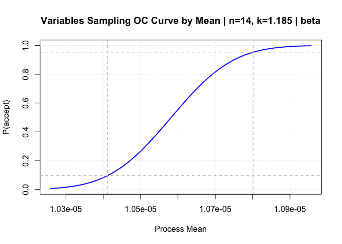

```r
# Plot OC curve be the process mean
plot(plan_beta, by = "mean")
```

## 3.4 Beta Distribution, Unknown Theta

Three methods are available when theta is estimated during inspection:

- `"delta_mle"` uses analytical Fisher-information covariance and is the default;
- `"delta_mom"` uses analytical covariance propagated from Beta raw moments;
- `"gk_adjustment"` retains the earlier Govindaraju–Kissling sample-size adjustment.

The supplied `theta` is the planning/reference precision used to construct the OC curve; `theta_type = "unknown"` means the inspection statistic estimates it.

```r
# Create a variable plan using Beta distribution
plan_beta2 <- optPlan(
  PRQ = 0.05,
  CRQ = 0.2,
  alpha = 0.05,
  beta = 0.10,
  distribution = "beta",
  theta = 44000000,
  theta_type = "unknown",
  method = "delta_mle",
  LSL = 0.00001
)

# Summary
summary(plan_beta2)
```

```
#> Variables Acceptance Sampling Plan
#>  Distribution: beta
#>  Sample Size (n, rounded up): 23  [raw n = 22.88681 ]
#>  Acceptability Constant (k): 1.184
#>  Population Precision Parameter (theta): unknown
#>  Unknown-theta method: Delta-MLE
#>  Producer's Risk (PR = 0.05 ) at PRQ = 0.05
#>  Consumer's Risk (CR = 0.1 ) at CRQ = 0.2
#>  Lower Specification Limit (LSL): 1e-05
```

## 3.5 Variables Sampling Plan Output Note

When designing a variables acceptance sampling plan using `optPlan()` or `optVarPlan()`, the returned object includes two related quantities for the sample size:

- **`sample_size`** — for practical application, the final plan uses the smallest integer greater than or equal to the theoretical value (`ceiling(n)`).
- **`n`** — the sample size the plan is evaluated at. For known-theta Beta plans this is the delivered integer size (equal to `sample_size`); for other plans it is the raw (non-rounded) value from the optimization model.

For known-theta Beta plans, the search is refined so that both risks are met at the delivered (rounded-up) sample size: the sample size is rounded up from the solution of the two binding risk equations, and the producer and consumer risks are verified at that integer size. The reported `PR` and `CR` therefore describe the plan as applied.

Example:

```r
plan_beta2$sample_size  # integer sample size used in plan
```

```
#> [1] 23
```

```r
plan_beta2$n            # raw computed (non-rounded) value
```

```
#> [1] 22.88681
```

## 3.6 Estimating θ for Beta-Based Plans

For Beta-distributed quality characteristics, the precision parameter **θ** reflects the concentration of the distribution around the mean. If θ is unknown, it can be estimated from historical process data.

A practical approach is to use the `VGAM` package, which provides the `betaff` function for fitting a Beta distribution and obtaining θ:

```r
# Example data
y <- c(0.75, 0.68, 0.72, 0.70, 0.76)

# Fit Beta model
fit <- vglm(y ~ 1, betaff, data = data.frame(y = y))

# Extract estimated parameters
coef(fit, matrix = TRUE)
```

```
#>             logitlink(mu) loglink(phi)
#> (Intercept)     0.9544037     5.410654
```

The output provides estimates of the mean (μ) and the precision parameter (θ). Use the estimated θ directly in `optPlan()`, e.g.:

```r
theta_est <- exp(coef(fit, matrix = TRUE)[1, "loglink(phi)"])
theta_est
```

```
#> [1] 223.7778
```

```r
optPlan(PRQ = 0.05, CRQ = 0.20, alpha = 0.05, beta = 0.10,
           USL = 0.8, distribution = "beta", theta_type = "unknown",
           theta = theta_est)
```

```
#> VarPlan object:
#>  Distribution: beta
#>  Theta type: unknown
#>  Unknown-theta method: Delta-MLE
#>  Sample size (n): 23
#>  Acceptability constant (k): 1.177434
#>
#> NOTE: summary(plan) for detail report,
#>       plot(plan) for quick OC visualization,
#>       OCdata(plan) to extract data for evaluation and custom plots.
```

## 3.7 Optimization Approach for Sampling Plans

The **AccSamplingDesign** package determines optimal sample sizes and acceptance criteria for variable sampling plans via numerical optimization.

- **Normal Plans (σ unknown):** Optimization is performed using the derivative-free method of Nelder and Mead (1965) via the `optim()` function in R. This method is robust for the non-linear objective functions that arise when σ is unknown.
- **Beta Plans:** Optimization is performed using the `optim()` function in R with the `"L-BFGS-B"` method (Byrd et al., 1995), which efficiently handles bound constraints on sample size and acceptance numbers. The constrained search is refined with the Nelder-Mead method to the solution of the two binding risk equations. For known-theta plans, the sample size is rounded up from that solution and both risks are verified at the delivered integer size, so the plan meets the producer and consumer risk constraints as applied.

This approach ensures stable and efficient plan calculations while relying solely on base R functionality, avoiding additional package dependencies.

# 4 Custom Plan Comparison

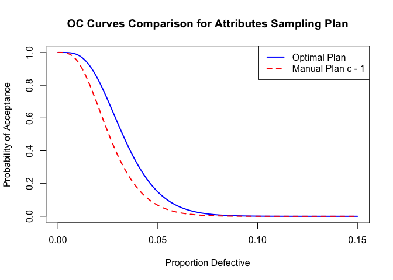

```r
# Define range of defect rates
pd <- seq(0, 0.15, by = 0.001)

# Generate OC data from optimal plan
oc_opt <- OCdata(plan = plan_attr, pd = pd)

# Compare with manual plans
mplan1 <- manualPlan(n = plan_attr$n, c = plan_attr$c - 1, distribution = "binomial")
oc_alt1 <- OCdata(plan = mplan1, pd = pd)

# Plot comparison
plot(pd, oc_opt$paccept, type = "l", col = "blue", lwd = 2,
     xlab = "Proportion Defective", ylab = "Probability of Acceptance",
     main = "OC Curves Comparison for Attributes Sampling Plan")
lines(pd, oc_alt1$paccept, col = "red", lwd = 2, lty = 2)
legend("topright", legend = c("Optimal Plan", "Manual Plan c - 1"),
       col = c("blue", "red"), lty = c(1, 2), lwd = 2)
```

# 5 References

This vignette provides a quick start for using the **AccSamplingDesign** package. For a full discussion of the statistical foundations, models, and optimization methods used, please refer to the foundation sources such as:

- Schilling, E.G., & Neubauer, D.V. (2017). Acceptance Sampling in Quality Control (3rd ed.). CRC Press.
- Wilrich, P.T. (2004). Single Sampling Plans for Inspection by Variables under a Variance Component Situation. In Frontiers in Statistical Quality Control 7.
- Truong, H., Miranda, V., & Kissling, R. (2026). AccSamplingDesign: An R Package for Optimizing Acceptance Sampling Plans. *The R Journal*, 18(1), 368–381. https://doi.org/10.32614/RJ-2026-007
- Govindaraju, K., & Kissling, R. (2015). Sampling plans for Beta-distributed compositional fractions. Quality Engineering, 27(1), 1–13.
- J. A. Nelder and R. Mead. A simplex method for function minimization. The Computer Journal, 7(4): 308–313, 1965. DOI 10.1093/comjnl/7.4.308.
- R. H. Byrd, P. Lu, J. Nocedal and C. Zhu. A limited memory algorithm for bound constrained optimization. SIAM Journal on Scientific Computing, 16(5): 1190–1208, 1995. DOI 10.1137/0916069.